# RMarkdown for “Variations in Structural MRI Quality Significantly Impacts Commonly-Used Measures of Brain Anatomy [Revised]”

Jamie Hanson

03/11/2021

# Starting Steps

First, we load relevant libraries, needed for various operations (using the pacman library).

```r
library(pacman)
pacman::p_load(dplyr,ggplot2,pROC,car,corrplot,caret, gt, gtsummary,rcompanion)
```

Next, load data (from the related/included csv file) One subject is removed because they did not complete CAT12 processing

```r
combined<-read.csv("HBN_combined_2021_03_04_full.csv")
combined<-subset(combined,combined$CAT12_QC_Weighted_Average!="NA")
```

# Methods

For elements our methods section, we note sample demographics, means. etc. This is related to **Methods Section 2.5**. First, we recode and rename variables to make naming more appropriate for table 1 (the R library).

Notes re: variables–  
-Basic_Demos.Sex = Participant Sex (coded Male / Female)  
-Diagnosis_ClinicianConsensus.NoDX = Participant Clinical Diagnoses (coded as No / Yes)  
-Basic_Demos.Age = Participant Age (coded in # of years)  
-WISC.WISC_FSIQ = Participant Wechsler Intelligence Scale for Children, Full Scale IQ (continuous measure)  
-Physical.BMI = Participant BMI (continuous measure)  
-CAT12_QC_Weighted_Average = MRI Quality Rating (continuous measure)

```r
combined$Basic_Demos.Sex<-car::recode(combined$Basic_Demos.Sex,'0="Male";1="Female"')
combined$Diagnosis_ClinicianConsensus.NoDX<-car::recode(combined$Diagnosis_ClinicianConsensus.NoDX,'1="No History";2="One or more Disorder"')
combined$Sex<-as.factor(combined$Basic_Demos.Sex)
combined$Age<-as.numeric(combined$Basic_Demos.Age)
combined$Diagnosis<-as.factor(combined$Diagnosis_ClinicianConsensus.NoDX)
combined$IQ<-as.numeric(combined$WISC.WISC_FSIQ)
combined$BMI<-as.numeric(combined$Physical.BMI)
combined$StructuralMRIQuality<-as.numeric(combined$CAT12_QC_Weighted_Average)
```

Construction of **Table 1** (via gtmmary R package)

```r
combined_table <- combined %>% select(Sex, Age, Diagnosis, IQ,BMI,StructuralMRIQuality,SurfaceHoles)
combined_table %>% tbl_summary(statistic = list(all_continuous() ~ "{mean} ({sd})"),label = list(Age ~ "Age (in Years)",IQ ~ "General Cognitive Ability",StructuralMRIQuality~"Structural MRI Quality, CAT12 Toolbox", SurfaceHoles~"Freesurfer Euler Number"), missing_text = "[Missing]") %>% bold_labels() %>% modify_header(label ~ "**Sample Characteristics**")
```

| **Sample Characteristics** | **N = 387**<sup>1</sup> |
| --- | --- |
| Sex |  |
| Female | 142 (37%) |
| Male | 245 (63%) |
| Age (in Years) | 10.1 (3.4) |
| Diagnosis |  |
| No History | 60 (16%) |
| One or more Disorder | 306 (84%) |
| [Missing] | 21 |
| General Cognitive Ability | 98 (17) |
| [Missing] | 52 |
| BMI | 19.5 (5.2) |
| [Missing] | 8 |
| Structural MRI Quality, CAT12 Toolbox | 0.83 (0.07) |
| Freesurfer Euler Number | 113 (107) |
| [Missing] | 24 |

<sup>*1*</sup> n (%); Mean (SD)

# Results

Analyses related to CAT 12 QC Ratings, and Passing [yes/no]. This is related to **Results, Section 4.1**

```r
summary(model_CAT12_pass<-glm(passing~ CAT12_QC_Weighted_Average , family = "binomial", data=combined))
```

```
## Warning: glm.fit: fitted probabilities numerically 0 or 1 occurred
```

```
##
## Call:
## glm(formula = passing ~ CAT12_QC_Weighted_Average, family = "binomial",
##     data = combined)
##
## Deviance Residuals:
##      Min        1Q    Median        3Q       Max
## -2.54796  -0.04294   0.06950   0.12925   2.31214
##
## Coefficients:
##                           Estimate Std. Error z value Pr(>|z|)
## (Intercept)                 -96.29      12.27  -7.848 4.24e-15 ***
## CAT12_QC_Weighted_Average   114.10      14.49   7.877 3.36e-15 ***
## ---
## Signif. codes:  0 '***' 0.001 '**' 0.01 '*' 0.05 '.' 0.1 ' ' 1
##
## (Dispersion parameter for binomial family taken to be 1)
##
##     Null deviance: 534.01  on 386  degrees of freedom
## Residual deviance: 105.60  on 385  degrees of freedom
## AIC: 109.6
##
## Number of Fisher Scoring iterations: 8
```

```r
nagelkerke(model_CAT12_pass)
```

```
## $Models
##
## Model: "glm, passing ~ CAT12_QC_Weighted_Average, binomial, combined"
## Null:  "glm, passing ~ 1, binomial, combined"
##
## $Pseudo.R.squared.for.model.vs.null
##                              Pseudo.R.squared
## McFadden                             0.802244
## Cox and Snell (ML)                   0.669449
## Nagelkerke (Cragg and Uhler)         0.894520
##
## $Likelihood.ratio.test
##  Df.diff LogLik.diff  Chisq    p.value
##       -1      -214.2 428.41 3.6116e-95
##
## $Number.of.observations
##
## Model: 387
## Null:  387
##
## $Messages
## [1] "Note: For models fit with REML, these statistics are based on refitting with ML"
##
## $Warnings
## [1] "None"
```

We also completed a **Bayesian GLM**, as a supplemental analysis (given the warning message in the above “frequentist” GLM

```r
suppressMessages(library(arm))
summary(bayesglm(passing ~ CAT12_QC_Weighted_Average, data=combined, family="binomial"))
```

```
##
## Call:
## bayesglm(formula = passing ~ CAT12_QC_Weighted_Average, family = "binomial",
##     data = combined)
##
## Deviance Residuals:
##      Min        1Q    Median        3Q       Max
## -2.51505  -0.04799   0.07575   0.13821   2.27601
##
## Coefficients:
##                           Estimate Std. Error z value Pr(>|z|)
## (Intercept)                 -93.36      11.51  -8.108 5.14e-16 ***
## CAT12_QC_Weighted_Average   110.64      13.59   8.141 3.94e-16 ***
## ---
## Signif. codes:  0 '***' 0.001 '**' 0.01 '*' 0.05 '.' 0.1 ' ' 1
##
## (Dispersion parameter for binomial family taken to be 1)
##
##     Null deviance: 534.01  on 386  degrees of freedom
## Residual deviance: 105.66  on 385  degrees of freedom
## AIC: 109.66
##
## Number of Fisher Scoring iterations: 11
```

Generating **Figure 2** (ROC Curve with confidence intervals)

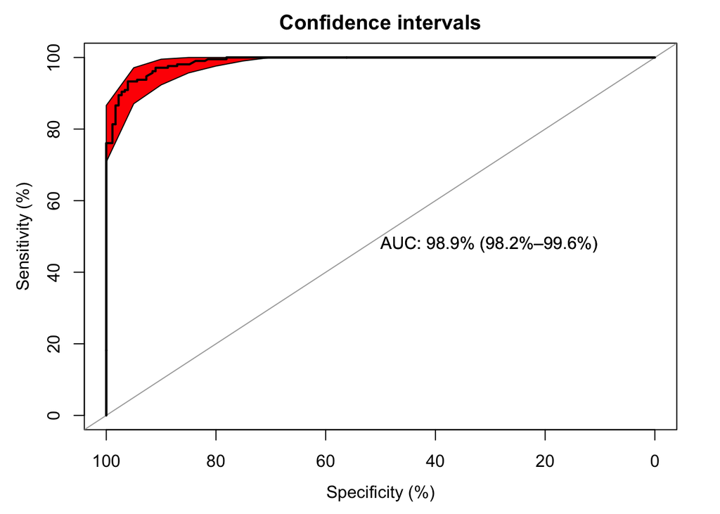

```r
roc<-plot.roc(combined$passing, combined$CAT12_QC_Weighted_Average,main = "Confidence intervals", percent=TRUE,ci = TRUE,print.auc = TRUE, asp = NA,direction="auto")
ciobj <- ci.se(roc,specificities = seq(0, 100, 5))
plot(ciobj, type = "shape", col = "red")
```

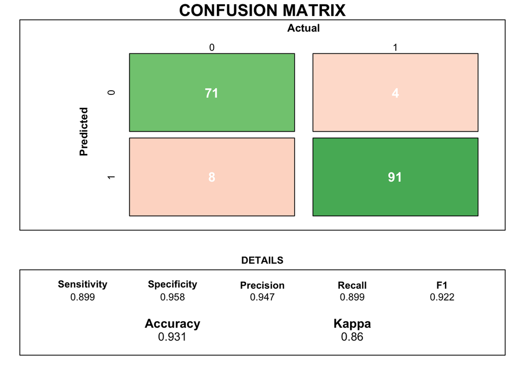

```r
train.rows <- sample(nrow(combined),0.80*nrow(combined),replace=TRUE)
TRAIN <- combined[train.rows,]
HOLDOUT <- combined[-train.rows,]

logitMod <- glm(passing ~ CAT12_QC_Weighted_Average, data=TRAIN, family=binomial(link="logit"))
pdata <- predict(logitMod, newdata = HOLDOUT, type = "response")
predicted<-factor(as.numeric(pdata>0.5))
HOLDOUT$passing<-factor(HOLDOUT$passing)

cm<-confusionMatrix(predicted, HOLDOUT$passing)

## Figure 3: Confusion Matrix, using R code found here-- https://stackoverflow.com/questions/23891140/r-how-to-visualize-confusion-matrix-using-the-caret-package
draw_confusion_matrix <- function(cm) {

  total <- sum(cm$table)
  res <- as.numeric(cm$table)

  # Generate color gradients. Palettes come from RColorBrewer.
  greenPalette <- c("#F7FCF5","#E5F5E0","#C7E9C0","#A1D99B","#74C476","#41AB5D","#238B45","#006D2C","#00441B")
  redPalette <- c("#FFF5F0","#FEE0D2","#FCBBA1","#FC9272","#FB6A4A","#EF3B2C","#CB181D","#A50F15","#67000D")
  getColor <- function (greenOrRed = "green", amount = 0) {
    if (amount == 0)
      return("#FFFFFF")
    palette <- greenPalette
    if (greenOrRed == "red")
      palette <- redPalette
    colorRampPalette(palette)(100)[10 + ceiling(90 * amount / total)]
  }

  # set the basic layout
  layout(matrix(c(1,1,2)))
  par(mar=c(2,2,2,2))
  plot(c(100, 345), c(300, 450), type = "n", xlab="", ylab="", xaxt='n', yaxt='n')
  title('CONFUSION MATRIX', cex.main=2)

  # create the matrix
  classes = colnames(cm$table)
  rect(150, 430, 240, 370, col=getColor("green", res[1]))
  text(195, 435, classes[1], cex=1.2)
  rect(250, 430, 340, 370, col=getColor("red", res[3]))
  text(295, 435, classes[2], cex=1.2)
  text(125, 370, 'Predicted', cex=1.3, srt=90, font=2)
  text(245, 450, 'Actual', cex=1.3, font=2)
  rect(150, 305, 240, 365, col=getColor("red", res[2]))
  rect(250, 305, 340, 365, col=getColor("green", res[4]))
  text(140, 400, classes[1], cex=1.2, srt=90)
  text(140, 335, classes[2], cex=1.2, srt=90)

  # add in the cm results
  text(195, 400, res[1], cex=1.6, font=2, col='white')
  text(195, 335, res[2], cex=1.6, font=2, col='white')
  text(295, 400, res[3], cex=1.6, font=2, col='white')
  text(295, 335, res[4], cex=1.6, font=2, col='white')

  # add in the specifics
  plot(c(100, 0), c(100, 0), type = "n", xlab="", ylab="", main = "DETAILS", xaxt='n', yaxt='n')
  text(10, 85, names(cm$byClass[1]), cex=1.2, font=2)
  text(10, 70, round(as.numeric(cm$byClass[1]), 3), cex=1.2)
  text(30, 85, names(cm$byClass[2]), cex=1.2, font=2)
  text(30, 70, round(as.numeric(cm$byClass[2]), 3), cex=1.2)
  text(50, 85, names(cm$byClass[5]), cex=1.2, font=2)
  text(50, 70, round(as.numeric(cm$byClass[5]), 3), cex=1.2)
  text(70, 85, names(cm$byClass[6]), cex=1.2, font=2)
  text(70, 70, round(as.numeric(cm$byClass[6]), 3), cex=1.2)
  text(90, 85, names(cm$byClass[7]), cex=1.2, font=2)
  text(90, 70, round(as.numeric(cm$byClass[7]), 3), cex=1.2)

  # add in the accuracy information
  text(30, 35, names(cm$overall[1]), cex=1.5, font=2)
  text(30, 20, round(as.numeric(cm$overall[1]), 3), cex=1.4)
  text(70, 35, names(cm$overall[2]), cex=1.5, font=2)
  text(70, 20, round(as.numeric(cm$overall[2]), 3), cex=1.4)
}
draw_confusion_matrix(cm)
```

Results for relations between sociodemographics and MRI Quality  
**Results, Section 4.2**

```r
summary(lm(CAT12_QC_Weighted_Average~ combined$Basic_Demos.Age , data=combined))
```

```
##
## Call:
## lm(formula = CAT12_QC_Weighted_Average ~ combined$Basic_Demos.Age,
##     data = combined)
##
## Residuals:
##      Min       1Q   Median       3Q      Max
## -0.24479 -0.03043  0.01684  0.04584  0.09463
##
## Coefficients:
##                          Estimate Std. Error t value Pr(>|t|)
## (Intercept)              0.767135   0.010193  75.260  < 2e-16 ***
## combined$Basic_Demos.Age 0.006366   0.000956   6.659 9.52e-11 ***
## ---
## Signif. codes:  0 '***' 0.001 '**' 0.01 '*' 0.05 '.' 0.1 ' ' 1
##
## Residual standard error: 0.06333 on 385 degrees of freedom
## Multiple R-squared:  0.1033, Adjusted R-squared:  0.101
## F-statistic: 44.34 on 1 and 385 DF,  p-value: 9.522e-11
```

```r
lm.beta::lm.beta(lm(CAT12_QC_Weighted_Average~ combined$Basic_Demos.Age , data=combined))
```

```
##
## Call:
## lm(formula = CAT12_QC_Weighted_Average ~ combined$Basic_Demos.Age,
##     data = combined)
##
## Standardized Coefficients::
##              (Intercept) combined$Basic_Demos.Age
##                0.0000000                0.3213787
```

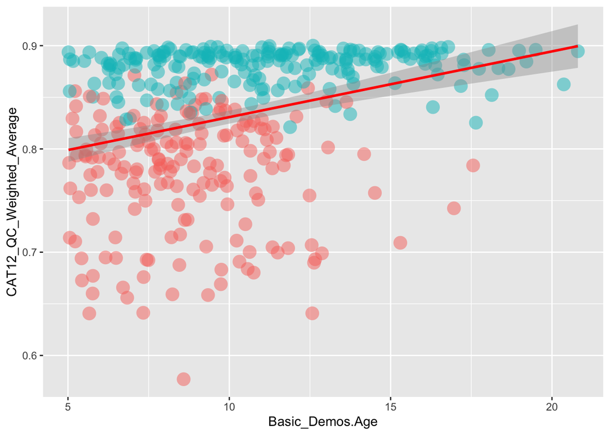

```r
combined$passing_label <- factor(combined$passing,
levels = c(0,1),
labels = c("Fail", "Pass"))
ggplot(combined, aes(y=CAT12_QC_Weighted_Average, x=Basic_Demos.Age, color=passing_label)) +geom_point(shape=16, size=5,alpha = 0.5,show.legend = FALSE) + geom_smooth(method=lm, color = 'red')
```

Additional Tests in **Results, Section 4.2** (all non-significant)

```r
summary(lm(CAT12_QC_Weighted_Average~ combined$Basic_Demos.Sex , data=combined))
```

```
##
## Call:
## lm(formula = CAT12_QC_Weighted_Average ~ combined$Basic_Demos.Sex,
##     data = combined)
##
## Residuals:
##      Min       1Q   Median       3Q      Max
## -0.26031 -0.03839  0.02059  0.05349  0.07181
##
## Coefficients:
##                               Estimate Std. Error t value Pr(>|t|)
## (Intercept)                   0.837312   0.005600 149.527   <2e-16 ***
## combined$Basic_Demos.SexMale -0.009119   0.007038  -1.296    0.196
## ---
## Signif. codes:  0 '***' 0.001 '**' 0.01 '*' 0.05 '.' 0.1 ' ' 1
##
## Residual standard error: 0.06673 on 385 degrees of freedom
## Multiple R-squared:  0.004342,   Adjusted R-squared:  0.001756
## F-statistic: 1.679 on 1 and 385 DF,  p-value: 0.1958
```

```r
summary(lm(CAT12_QC_Weighted_Average~ combined$WISC.WISC_FSIQ , data=combined))
```

```
##
## Call:
## lm(formula = CAT12_QC_Weighted_Average ~ combined$WISC.WISC_FSIQ,
##     data = combined)
##
## Residuals:
##      Min       1Q   Median       3Q      Max
## -0.25673 -0.03981  0.02371  0.05312  0.08403
##
## Coefficients:
##                          Estimate Std. Error t value Pr(>|t|)
## (Intercept)             0.7944234  0.0212365  37.408   <2e-16 ***
## combined$WISC.WISC_FSIQ 0.0003971  0.0002128   1.866    0.063 .
## ---
## Signif. codes:  0 '***' 0.001 '**' 0.01 '*' 0.05 '.' 0.1 ' ' 1
##
## Residual standard error: 0.06571 on 333 degrees of freedom
##   (52 observations deleted due to missingness)
## Multiple R-squared:  0.01034,    Adjusted R-squared:  0.007372
## F-statistic:  3.48 on 1 and 333 DF,  p-value: 0.06298
```

```r
lm.beta::lm.beta(lm(CAT12_QC_Weighted_Average~ combined$WISC.WISC_FSIQ , data=combined))
```

```
##
## Call:
## lm(formula = CAT12_QC_Weighted_Average ~ combined$WISC.WISC_FSIQ,
##     data = combined)
##
## Standardized Coefficients::
##             (Intercept) combined$WISC.WISC_FSIQ
##               0.0000000               0.1017036
```

```r
summary(lm(CAT12_QC_Weighted_Average~ combined$Physical.BMI , data=combined))
```

```
##
## Call:
## lm(formula = CAT12_QC_Weighted_Average ~ combined$Physical.BMI,
##     data = combined)
##
## Residuals:
##      Min       1Q   Median       3Q      Max
## -0.25233 -0.03903  0.02039  0.05508  0.07150
##
## Coefficients:
##                        Estimate Std. Error t value Pr(>|t|)
## (Intercept)           0.8160979  0.0132609  61.542   <2e-16 ***
## combined$Physical.BMI 0.0007959  0.0006584   1.209    0.227
## ---
## Signif. codes:  0 '***' 0.001 '**' 0.01 '*' 0.05 '.' 0.1 ' ' 1
##
## Residual standard error: 0.06662 on 377 degrees of freedom
##   (8 observations deleted due to missingness)
## Multiple R-squared:  0.003861,   Adjusted R-squared:  0.001219
## F-statistic: 1.461 on 1 and 377 DF,  p-value: 0.2275
```

```r
summary(lm(CAT12_QC_Weighted_Average~ combined$Diagnosis_ClinicianConsensus.NoDX , data=combined))
```

```
##
## Call:
## lm(formula = CAT12_QC_Weighted_Average ~ combined$Diagnosis_ClinicianConsensus.NoDX,
##     data = combined)
##
## Residuals:
##      Min       1Q   Median       3Q      Max
## -0.25163 -0.04105  0.02180  0.05647  0.07136
##
## Coefficients:
##                                                                 Estimate
## (Intercept)                                                     0.841258
## combined$Diagnosis_ClinicianConsensus.NoDXOne or more Disorder -0.012624
##                                                                Std. Error
## (Intercept)                                                      0.008779
## combined$Diagnosis_ClinicianConsensus.NoDXOne or more Disorder   0.009601
##                                                                t value Pr(>|t|)
## (Intercept)                                                     95.828   <2e-16
## combined$Diagnosis_ClinicianConsensus.NoDXOne or more Disorder  -1.315    0.189
##
## (Intercept)                                                    ***
## combined$Diagnosis_ClinicianConsensus.NoDXOne or more Disorder
## ---
## Signif. codes:  0 '***' 0.001 '**' 0.01 '*' 0.05 '.' 0.1 ' ' 1
##
## Residual standard error: 0.068 on 364 degrees of freedom
##   (21 observations deleted due to missingness)
## Multiple R-squared:  0.004727,   Adjusted R-squared:  0.001993
## F-statistic: 1.729 on 1 and 364 DF,  p-value: 0.1894
```

Additional Analyses in **Results, Section 4.2** (only the subjects that pass visual inspection)

```r
OnlySubsPassingVisualQC<-subset(combined,combined$passing==1)
summary(lm(CAT12_QC_Weighted_Average~ Basic_Demos.Age , data=OnlySubsPassingVisualQC))
```

```
##
## Call:
## lm(formula = CAT12_QC_Weighted_Average ~ Basic_Demos.Age, data = OnlySubsPassingVisualQC)
##
## Residuals:
##       Min        1Q    Median        3Q       Max
## -0.059566 -0.008473  0.006150  0.011464  0.020412
##
## Coefficients:
##                  Estimate Std. Error t value Pr(>|t|)
## (Intercept)     0.8724908  0.0038720 225.332   <2e-16 ***
## Basic_Demos.Age 0.0006879  0.0003263   2.108   0.0362 *
## ---
## Signif. codes:  0 '***' 0.001 '**' 0.01 '*' 0.05 '.' 0.1 ' ' 1
##
## Residual standard error: 0.01696 on 207 degrees of freedom
## Multiple R-squared:  0.02102,    Adjusted R-squared:  0.01629
## F-statistic: 4.445 on 1 and 207 DF,  p-value: 0.03621
```

```r
summary(lm(CAT12_QC_Weighted_Average~ Basic_Demos.Sex , data=OnlySubsPassingVisualQC))
```

```
##
## Call:
## lm(formula = CAT12_QC_Weighted_Average ~ Basic_Demos.Sex, data = OnlySubsPassingVisualQC)
##
## Residuals:
##       Min        1Q    Median        3Q       Max
## -0.057692 -0.006692  0.006416  0.012008  0.020008
##
## Coefficients:
##                     Estimate Std. Error t value Pr(>|t|)
## (Intercept)         0.878792   0.001855 473.851   <2e-16 ***
## Basic_Demos.SexMale 0.002492   0.002408   1.035    0.302
## ---
## Signif. codes:  0 '***' 0.001 '**' 0.01 '*' 0.05 '.' 0.1 ' ' 1
##
## Residual standard error: 0.0171 on 207 degrees of freedom
## Multiple R-squared:  0.005149,   Adjusted R-squared:  0.0003428
## F-statistic: 1.071 on 1 and 207 DF,  p-value: 0.3019
```

```r
summary(lm(CAT12_QC_Weighted_Average~ WISC.WISC_FSIQ , data=OnlySubsPassingVisualQC))
```

```
##
## Call:
## lm(formula = CAT12_QC_Weighted_Average ~ WISC.WISC_FSIQ, data = OnlySubsPassingVisualQC)
##
## Residuals:
##      Min       1Q   Median       3Q      Max
## -0.05917 -0.00777  0.00639  0.01163  0.02022
##
## Coefficients:
##                 Estimate Std. Error t value Pr(>|t|)
## (Intercept)    8.762e-01  6.659e-03  131.57   <2e-16 ***
## WISC.WISC_FSIQ 4.467e-05  6.665e-05    0.67    0.504
## ---
## Signif. codes:  0 '***' 0.001 '**' 0.01 '*' 0.05 '.' 0.1 ' ' 1
##
## Residual standard error: 0.01695 on 183 degrees of freedom
##   (24 observations deleted due to missingness)
## Multiple R-squared:  0.002449,   Adjusted R-squared:  -0.003002
## F-statistic: 0.4492 on 1 and 183 DF,  p-value: 0.5035
```

```r
summary(lm(CAT12_QC_Weighted_Average~ Physical.BMI , data=OnlySubsPassingVisualQC))
```

```
##
## Call:
## lm(formula = CAT12_QC_Weighted_Average ~ Physical.BMI, data = OnlySubsPassingVisualQC)
##
## Residuals:
##       Min        1Q    Median        3Q       Max
## -0.059056 -0.006997  0.006650  0.012297  0.019837
##
## Coefficients:
##                Estimate Std. Error t value Pr(>|t|)
## (Intercept)   0.8836391  0.0045000 196.366   <2e-16 ***
## Physical.BMI -0.0001687  0.0002169  -0.778    0.438
## ---
## Signif. codes:  0 '***' 0.001 '**' 0.01 '*' 0.05 '.' 0.1 ' ' 1
##
## Residual standard error: 0.01725 on 202 degrees of freedom
##   (5 observations deleted due to missingness)
## Multiple R-squared:  0.002984,   Adjusted R-squared:  -0.001952
## F-statistic: 0.6045 on 1 and 202 DF,  p-value: 0.4378
```

```r
summary(lm(CAT12_QC_Weighted_Average~ factor(Diagnosis_ClinicianConsensus.NoDX) , data=OnlySubsPassingVisualQC))
```

```
##
## Call:
## lm(formula = CAT12_QC_Weighted_Average ~ factor(Diagnosis_ClinicianConsensus.NoDX),
##     data = OnlySubsPassingVisualQC)
##
## Residuals:
##      Min       1Q   Median       3Q      Max
## -0.05975 -0.00645  0.00605  0.01175  0.01915
##
## Coefficients:
##                                                                 Estimate
## (Intercept)                                                    8.809e-01
## factor(Diagnosis_ClinicianConsensus.NoDX)One or more Disorder -9.381e-05
##                                                               Std. Error
## (Intercept)                                                    2.886e-03
## factor(Diagnosis_ClinicianConsensus.NoDX)One or more Disorder  3.173e-03
##                                                               t value Pr(>|t|)
## (Intercept)                                                    305.24   <2e-16
## factor(Diagnosis_ClinicianConsensus.NoDX)One or more Disorder   -0.03    0.976
##
## (Intercept)                                                   ***
## factor(Diagnosis_ClinicianConsensus.NoDX)One or more Disorder
## ---
## Signif. codes:  0 '***' 0.001 '**' 0.01 '*' 0.05 '.' 0.1 ' ' 1
##
## Residual standard error: 0.01683 on 195 degrees of freedom
##   (12 observations deleted due to missingness)
## Multiple R-squared:  4.483e-06,  Adjusted R-squared:  -0.005124
## F-statistic: 0.0008742 on 1 and 195 DF,  p-value: 0.9764
```

Results for relations between Freesurfer Outputs and MRI Quality, **Results, Section 4.3**. We complete some looped regressions, save relevant statistics, multiple-comparison correction, and then prep for Figure construction.

Analyses for Cortical Surface Area  
We select the relevant Cortical Area outputs below  
Remove some additional, non-area related variables  
And then put CAT12 QC measures “back in” our dataframe

```r
OnlySubsPassingVisualQC_Freesurfer_AREA<-OnlySubsPassingVisualQC[,78:147]
OnlySubsPassingVisualQC_Freesurfer_AREA<-OnlySubsPassingVisualQC_Freesurfer_AREA %>% dplyr::select(-c(lh_WhiteSurfArea_area,eTIV))
OnlySubsPassingVisualQC_Freesurfer_AREA$CAT12_QC_Weighted_Average<-OnlySubsPassingVisualQC$CAT12_QC_Weighted_Average
AREA_for_Figure<-OnlySubsPassingVisualQC_Freesurfer_AREA[,1:68]
CAT12Ratings<-OnlySubsPassingVisualQC_Freesurfer_AREA[,69]
```

Now we run a loop of regression  
Each examines a brain parcel’s area  
in Relation to Structural MRI  
There’s also some column collapsing, renaming, etc.

```r
## Regression Loop, with Area as DV and  QC as IV

n<-68
AREA_Loop_to_Extract_Tstats <- lapply(1:n, function(x) lm(AREA_for_Figure[,x] ~  CAT12Ratings))

## Pull out T-Statistics from Regressions
AREA_summaries <- lapply(AREA_Loop_to_Extract_Tstats, summary)
AREA_saved_T<-lapply(AREA_summaries, function(x) x$coefficients[, c(3)])
AREA_T_Statistics_temp<-lapply(AREA_saved_T, function (x) x[c('CAT12Ratings')])
AREA_just_T_Statistics<-do.call(rbind.data.frame, AREA_T_Statistics_temp)
names(AREA_just_T_Statistics)[1] <- "T_stat"

## Rename and Reorder the data frames (related to t-statistics)
AREA_just_T_Statistics$BrainRegions<-(colnames(OnlySubsPassingVisualQC_Freesurfer_AREA)[1:68])
AREA_just_T_Statistics<-AREA_just_T_Statistics[, c(2,1)]

## Pull out P-Values from Regressions
AREA_saved_p<-lapply(AREA_summaries, function(x) x$coefficients[, c(4)])
AREA_p_Statistics_temp<-lapply(AREA_saved_p, function (x) x[c('CAT12Ratings')])
AREA_just_p_Statistics<-do.call(rbind.data.frame, AREA_p_Statistics_temp)
names(AREA_just_p_Statistics)[1] <- "pvalue"

## Rename and Reorder the data frames (related to p-values)
AREA_just_p_Statistics$BrainRegions<-(colnames(OnlySubsPassingVisualQC_Freesurfer_AREA)[1:68])
AREA_just_p_Statistics<-AREA_just_p_Statistics[, c(2,1)]
```

We make our ggseg figures out, tibbl-ing our data  
We make two versions, one with just t-values  
and one noting which reasons survive multiple comparisons  
we then combine the two panels in cowplot  
**Figure 5**

```r
# load relevant R libraries

library(ggseg); library(ggseg3d); library(tidyverse);library(stats);library(gt);library(cowplot)
# Make tibble to eventually put into ggseg [for t-statistics]
dk_statistical_values_AREA_T=tibble(
  label=c("lh_bankssts",
          "lh_caudalanteriorcingulate",
          "lh_caudalmiddlefrontal",
          "lh_cuneus",
          "lh_entorhinal",
          "lh_fusiform",
          "lh_inferiorparietal",
          "lh_inferiortemporal",
          "lh_isthmuscingulate",
          "lh_lateraloccipital",
          "lh_lateralorbitofrontal",
          "lh_lingual",
          "lh_medialorbitofrontal",
          "lh_middletemporal",
          "lh_parahippocampal",
          "lh_paracentral",
          "lh_parsopercularis",
          "lh_parsorbitalis",
          "lh_parstriangularis",
          "lh_pericalcarine",
          "lh_postcentral",
          "lh_posteriorcingulate",
          "lh_precentral",
          "lh_precuneus",
          "lh_rostralanteriorcingulate",
          "lh_rostralmiddlefrontal",
          "lh_superiorfrontal",
          "lh_superiorparietal",
          "lh_superiortemporal",
          "lh_supramarginal",
          "lh_frontalpole",
          "lh_temporalpole",
          "lh_transversetemporal",
          "lh_insula",
          "rh_bankssts",
          "rh_caudalanteriorcingulate",
          "rh_caudalmiddlefrontal",
          "rh_cuneus",
          "rh_entorhinal",
          "rh_fusiform",
          "rh_inferiorparietal",
          "rh_inferiortemporal",
          "rh_isthmuscingulate",
          "rh_lateraloccipital",
          "rh_lateralorbitofrontal",
          "rh_lingual",
          "rh_medialorbitofrontal",
          "rh_middletemporal",
          "rh_parahippocampal",
          "rh_paracentral",
          "rh_parsopercularis",
          "rh_parsorbitalis",
          "rh_parstriangularis",
          "rh_pericalcarine",
          "rh_postcentral",
          "rh_posteriorcingulate",
          "rh_precentral",
          "rh_precuneus",
          "rh_rostralanteriorcingulate",
          "rh_rostralmiddlefrontal",
          "rh_superiorfrontal",
          "rh_superiorparietal",
          "rh_superiortemporal",
          "rh_supramarginal",
          "rh_frontalpole",
          "rh_temporalpole",
          "rh_transversetemporal",
          "rh_insula"),
  t=c(AREA_just_T_Statistics$T_stat[1],
      AREA_just_T_Statistics$T_stat[2],
      AREA_just_T_Statistics$T_stat[3],
      AREA_just_T_Statistics$T_stat[4],
      AREA_just_T_Statistics$T_stat[5],
      AREA_just_T_Statistics$T_stat[6],
      AREA_just_T_Statistics$T_stat[7],
      AREA_just_T_Statistics$T_stat[8],
      AREA_just_T_Statistics$T_stat[9],
      AREA_just_T_Statistics$T_stat[10],
      AREA_just_T_Statistics$T_stat[11],
      AREA_just_T_Statistics$T_stat[12],
      AREA_just_T_Statistics$T_stat[13],
      AREA_just_T_Statistics$T_stat[14],
      AREA_just_T_Statistics$T_stat[15],
      AREA_just_T_Statistics$T_stat[16],
      AREA_just_T_Statistics$T_stat[17],
      AREA_just_T_Statistics$T_stat[18],
      AREA_just_T_Statistics$T_stat[19],
      AREA_just_T_Statistics$T_stat[20],
      AREA_just_T_Statistics$T_stat[21],
      AREA_just_T_Statistics$T_stat[22],
      AREA_just_T_Statistics$T_stat[23],
      AREA_just_T_Statistics$T_stat[24],
      AREA_just_T_Statistics$T_stat[25],
      AREA_just_T_Statistics$T_stat[26],
      AREA_just_T_Statistics$T_stat[27],
      AREA_just_T_Statistics$T_stat[28],
      AREA_just_T_Statistics$T_stat[29],
      AREA_just_T_Statistics$T_stat[30],
      AREA_just_T_Statistics$T_stat[31],
      AREA_just_T_Statistics$T_stat[32],
      AREA_just_T_Statistics$T_stat[33],
      AREA_just_T_Statistics$T_stat[34],
      AREA_just_T_Statistics$T_stat[35],
      AREA_just_T_Statistics$T_stat[36],
      AREA_just_T_Statistics$T_stat[37],
      AREA_just_T_Statistics$T_stat[38],
      AREA_just_T_Statistics$T_stat[39],
      AREA_just_T_Statistics$T_stat[40],
      AREA_just_T_Statistics$T_stat[41],
      AREA_just_T_Statistics$T_stat[42],
      AREA_just_T_Statistics$T_stat[43],
      AREA_just_T_Statistics$T_stat[44],
      AREA_just_T_Statistics$T_stat[45],
      AREA_just_T_Statistics$T_stat[46],
      AREA_just_T_Statistics$T_stat[47],
      AREA_just_T_Statistics$T_stat[48],
      AREA_just_T_Statistics$T_stat[49],
      AREA_just_T_Statistics$T_stat[50],
      AREA_just_T_Statistics$T_stat[51],
      AREA_just_T_Statistics$T_stat[52],
      AREA_just_T_Statistics$T_stat[53],
      AREA_just_T_Statistics$T_stat[54],
      AREA_just_T_Statistics$T_stat[55],
      AREA_just_T_Statistics$T_stat[56],
      AREA_just_T_Statistics$T_stat[57],
      AREA_just_T_Statistics$T_stat[58],
      AREA_just_T_Statistics$T_stat[59],
      AREA_just_T_Statistics$T_stat[60],
      AREA_just_T_Statistics$T_stat[61],
      AREA_just_T_Statistics$T_stat[62],
      AREA_just_T_Statistics$T_stat[63],
      AREA_just_T_Statistics$T_stat[64],
      AREA_just_T_Statistics$T_stat[65],
      AREA_just_T_Statistics$T_stat[66],
      AREA_just_T_Statistics$T_stat[67],
      AREA_just_T_Statistics$T_stat[68]))

# Make tibble to eventually put into ggseg [for p-values]
dk_statistical_values_AREA_p=tibble(
label=c("lh_bankssts",
          "lh_caudalanteriorcingulate",
          "lh_caudalmiddlefrontal",
          "lh_cuneus",
          "lh_entorhinal",
          "lh_fusiform",
          "lh_inferiorparietal",
          "lh_inferiortemporal",
          "lh_isthmuscingulate",
          "lh_lateraloccipital",
          "lh_lateralorbitofrontal",
          "lh_lingual",
          "lh_medialorbitofrontal",
          "lh_middletemporal",
          "lh_parahippocampal",
          "lh_paracentral",
          "lh_parsopercularis",
          "lh_parsorbitalis",
          "lh_parstriangularis",
          "lh_pericalcarine",
          "lh_postcentral",
          "lh_posteriorcingulate",
          "lh_precentral",
          "lh_precuneus",
          "lh_rostralanteriorcingulate",
          "lh_rostralmiddlefrontal",
          "lh_superiorfrontal",
          "lh_superiorparietal",
          "lh_superiortemporal",
          "lh_supramarginal",
          "lh_frontalpole",
          "lh_temporalpole",
          "lh_transversetemporal",
          "lh_insula",
          "rh_bankssts",
          "rh_caudalanteriorcingulate",
          "rh_caudalmiddlefrontal",
          "rh_cuneus",
          "rh_entorhinal",
          "rh_fusiform",
          "rh_inferiorparietal",
          "rh_inferiortemporal",
          "rh_isthmuscingulate",
          "rh_lateraloccipital",
          "rh_lateralorbitofrontal",
          "rh_lingual",
          "rh_medialorbitofrontal",
          "rh_middletemporal",
          "rh_parahippocampal",
          "rh_paracentral",
          "rh_parsopercularis",
          "rh_parsorbitalis",
          "rh_parstriangularis",
          "rh_pericalcarine",
          "rh_postcentral",
          "rh_posteriorcingulate",
          "rh_precentral",
          "rh_precuneus",
          "rh_rostralanteriorcingulate",
          "rh_rostralmiddlefrontal",
          "rh_superiorfrontal",
          "rh_superiorparietal",
          "rh_superiortemporal",
          "rh_supramarginal",
          "rh_frontalpole",
          "rh_temporalpole",
          "rh_transversetemporal",
          "rh_insula"),
p=c(AREA_just_p_Statistics$pvalue[1],
      AREA_just_p_Statistics$pvalue[2],
      AREA_just_p_Statistics$pvalue[3],
      AREA_just_p_Statistics$pvalue[4],
      AREA_just_p_Statistics$pvalue[5],
      AREA_just_p_Statistics$pvalue[6],
      AREA_just_p_Statistics$pvalue[7],
      AREA_just_p_Statistics$pvalue[8],
      AREA_just_p_Statistics$pvalue[9],
      AREA_just_p_Statistics$pvalue[10],
      AREA_just_p_Statistics$pvalue[11],
      AREA_just_p_Statistics$pvalue[12],
      AREA_just_p_Statistics$pvalue[13],
      AREA_just_p_Statistics$pvalue[14],
      AREA_just_p_Statistics$pvalue[15],
      AREA_just_p_Statistics$pvalue[16],
      AREA_just_p_Statistics$pvalue[17],
      AREA_just_p_Statistics$pvalue[18],
      AREA_just_p_Statistics$pvalue[19],
      AREA_just_p_Statistics$pvalue[20],
      AREA_just_p_Statistics$pvalue[21],
      AREA_just_p_Statistics$pvalue[22],
      AREA_just_p_Statistics$pvalue[23],
      AREA_just_p_Statistics$pvalue[24],
      AREA_just_p_Statistics$pvalue[25],
      AREA_just_p_Statistics$pvalue[26],
      AREA_just_p_Statistics$pvalue[27],
      AREA_just_p_Statistics$pvalue[28],
      AREA_just_p_Statistics$pvalue[29],
      AREA_just_p_Statistics$pvalue[30],
      AREA_just_p_Statistics$pvalue[31],
      AREA_just_p_Statistics$pvalue[32],
      AREA_just_p_Statistics$pvalue[33],
      AREA_just_p_Statistics$pvalue[34],
      AREA_just_p_Statistics$pvalue[35],
      AREA_just_p_Statistics$pvalue[36],
      AREA_just_p_Statistics$pvalue[37],
      AREA_just_p_Statistics$pvalue[38],
      AREA_just_p_Statistics$pvalue[39],
      AREA_just_p_Statistics$pvalue[40],
      AREA_just_p_Statistics$pvalue[41],
      AREA_just_p_Statistics$pvalue[42],
      AREA_just_p_Statistics$pvalue[43],
      AREA_just_p_Statistics$pvalue[44],
      AREA_just_p_Statistics$pvalue[45],
      AREA_just_p_Statistics$pvalue[46],
      AREA_just_p_Statistics$pvalue[47],
      AREA_just_p_Statistics$pvalue[48],
      AREA_just_p_Statistics$pvalue[49],
      AREA_just_p_Statistics$pvalue[50],
      AREA_just_p_Statistics$pvalue[51],
      AREA_just_p_Statistics$pvalue[52],
      AREA_just_p_Statistics$pvalue[53],
      AREA_just_p_Statistics$pvalue[54],
      AREA_just_p_Statistics$pvalue[55],
      AREA_just_p_Statistics$pvalue[56],
      AREA_just_p_Statistics$pvalue[57],
      AREA_just_p_Statistics$pvalue[58],
      AREA_just_p_Statistics$pvalue[59],
      AREA_just_p_Statistics$pvalue[60],
      AREA_just_p_Statistics$pvalue[61],
      AREA_just_p_Statistics$pvalue[62],
      AREA_just_p_Statistics$pvalue[63],
      AREA_just_p_Statistics$pvalue[64],
      AREA_just_p_Statistics$pvalue[65],
      AREA_just_p_Statistics$pvalue[66],
      AREA_just_p_Statistics$pvalue[67],
      AREA_just_p_Statistics$pvalue[68]))

# We correct for multiple comparisons with this call
dk_statistical_values_AREA_p$p_adjusted<-p.adjust(dk_statistical_values_AREA_p$p, method = "BH", n = length(dk_statistical_values_AREA_p$p))

# We combine some dataframes
dk_statistical_values_AREA_T_p <- dk_statistical_values_AREA_T %>% left_join(dk_statistical_values_AREA_p)
# We select only regions that survive multiple comparisons, making others NA; we rename some columns
AREA_Multiple_Comparisons<-as_tibble(as.numeric(dk_statistical_values_AREA_p$p_adjusted<.05))
AREA_Multiple_Comparisons<-AREA_Multiple_Comparisons %>% mutate(value=recode(value,0,1))
names(AREA_Multiple_Comparisons)[names(AREA_Multiple_Comparisons)=="value"] <- "Survives_Multiple_Comparison_Correction"
dk_statistical_values_AREA_T_w_MultipleComparisons <- cbind(dk_statistical_values_AREA_T, AREA_Multiple_Comparisons)

# We make 2 figures (but store them)
AREA_p1<-ggseg(dk_statistical_values_AREA_T,atlas=dk,position = "stacked",mapping=aes(fill=t),colour="black") + scale_fill_gradient2(low = "#045a8d",high = "#de2d26",space = "Lab",limits = c(-6.75, 6.75)) +theme(legend.position = "bottom")
```

```
## merging atlas and data by 'label'
```

```r
AREA_p2<-ggseg(dk_statistical_values_AREA_T_w_MultipleComparisons,atlas=dk,position = "stacked",mapping=aes(fill=Survives_Multiple_Comparison_Correction),color="black")+theme(legend.position = "bottom")
```

```
## merging atlas and data by 'label'
```

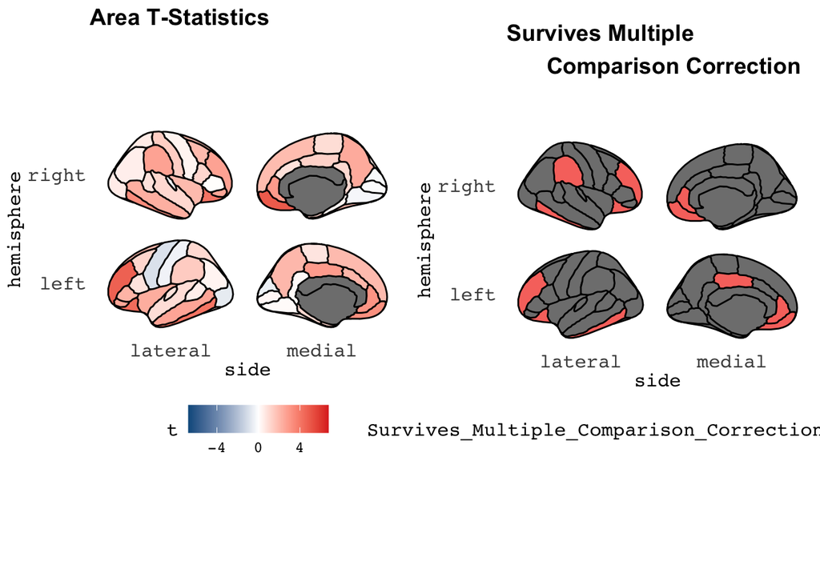

```r
# Then output and combine in cowplot
plot_grid(AREA_p1, AREA_p2,labels = c('Area T-Statistics', 'Survives Multiple \n Comparison Correction'))
```

We also output a Table showing the stats for  
QC and surface area  
with adjusted and unadjusted p-values  
For the folks who like tables, etc.  
**Table 2**

```r
dk_statistical_values_AREA_T_p %>% mutate_if(is.numeric, round, 5) %>% rename('t_statistics' = 't')  %>% rename('p_value' = 'p') %>% rename('Area Parcel' = 'label') %>% gt() %>% tab_style(style = cell_fill(color = "#fc9272"),locations = cells_body(columns = "p_adjusted", rows = (p_adjusted<.05)))  %>% tab_style(style = cell_fill(color = "#fee0d2"),locations = cells_body(columns = "p_value", rows = (p_value<.05))) %>% tab_options(table.font.size = "smaller",column_labels.font.size = "small",data_row.padding = px(1))
```

| Area Parcel | t_statistics | p_value | p_adjusted |
| --- | --- | --- | --- |
| lh_bankssts | 0.44371 | 0.65772 | 0.79866 |
| lh_caudalanteriorcingulate | 2.08777 | 0.03805 | 0.11760 |
| lh_caudalmiddlefrontal | 1.17122 | 0.24286 | 0.48195 |
| lh_cuneus | -0.44706 | 0.65530 | 0.79866 |
| lh_entorhinal | 1.22860 | 0.22062 | 0.45462 |
| lh_fusiform | 0.81376 | 0.41672 | 0.59110 |
| lh_inferiorparietal | 0.30567 | 0.76016 | 0.86025 |
| lh_inferiortemporal | 4.10177 | 0.00006 | 0.00080 |
| lh_isthmuscingulate | 0.18245 | 0.85541 | 0.89489 |
| lh_lateraloccipital | -0.61571 | 0.53877 | 0.73272 |
| lh_lateralorbitofrontal | 4.36176 | 0.00002 | 0.00046 |
| lh_lingual | 0.13832 | 0.89012 | 0.91709 |
| lh_medialorbitofrontal | 3.23941 | 0.00140 | 0.01357 |
| lh_middletemporal | 2.61381 | 0.00961 | 0.05029 |
| lh_parahippocampal | 1.09311 | 0.27562 | 0.49322 |
| lh_paracentral | 0.73901 | 0.46074 | 0.63940 |
| lh_parsopercularis | 0.81284 | 0.41725 | 0.59110 |
| lh_parsorbitalis | 2.54329 | 0.01172 | 0.05311 |
| lh_parstriangularis | 2.14037 | 0.03350 | 0.11390 |
| lh_pericalcarine | 0.23182 | 0.81691 | 0.88174 |
| lh_postcentral | -0.35881 | 0.72011 | 0.85907 |
| lh_posteriorcingulate | 2.88885 | 0.00428 | 0.02910 |
| lh_precentral | -0.92631 | 0.35537 | 0.56197 |
| lh_precuneus | 2.04056 | 0.04257 | 0.12586 |
| lh_rostralanteriorcingulate | 3.08607 | 0.00231 | 0.01961 |
| lh_rostralmiddlefrontal | 4.67811 | 0.00001 | 0.00018 |
| lh_superiorfrontal | 1.95419 | 0.05203 | 0.13748 |
| lh_superiorparietal | 1.06070 | 0.29007 | 0.49980 |
| lh_superiortemporal | 0.94196 | 0.34732 | 0.56197 |
| lh_supramarginal | 1.46012 | 0.14578 | 0.34183 |
| lh_frontalpole | 2.33001 | 0.02077 | 0.07848 |
| lh_temporalpole | 2.11599 | 0.03555 | 0.11510 |
| lh_transversetemporal | 0.85295 | 0.39468 | 0.59110 |
| lh_insula | 2.37299 | 0.01856 | 0.07426 |
| rh_bankssts | 0.83044 | 0.40725 | 0.59110 |
| rh_caudalanteriorcingulate | 0.85123 | 0.39563 | 0.59110 |
| rh_caudalmiddlefrontal | 1.93317 | 0.05459 | 0.13748 |
| rh_cuneus | -0.18496 | 0.85344 | 0.89489 |
| rh_entorhinal | 1.25415 | 0.21121 | 0.44882 |
| rh_fusiform | 1.93642 | 0.05418 | 0.13748 |
| rh_inferiorparietal | 0.46049 | 0.64565 | 0.79866 |
| rh_inferiortemporal | 3.35107 | 0.00096 | 0.01085 |
| rh_isthmuscingulate | 1.05208 | 0.29400 | 0.49980 |
| rh_lateraloccipital | 0.55048 | 0.58259 | 0.76184 |
| rh_lateralorbitofrontal | 4.10849 | 0.00006 | 0.00080 |
| rh_lingual | -0.25066 | 0.80233 | 0.87997 |
| rh_medialorbitofrontal | 4.91858 | 0.00000 | 0.00012 |
| rh_middletemporal | 2.29156 | 0.02294 | 0.08211 |
| rh_parahippocampal | 0.29054 | 0.77169 | 0.86025 |
| rh_paracentral | 0.96544 | 0.33546 | 0.55636 |
| rh_parsopercularis | 1.15082 | 0.25114 | 0.48195 |
| rh_parsorbitalis | 2.56615 | 0.01099 | 0.05311 |
| rh_parstriangularis | 0.04814 | 0.96165 | 0.96165 |
| rh_pericalcarine | -0.09957 | 0.92079 | 0.93453 |
| rh_postcentral | 1.38743 | 0.16681 | 0.37810 |
| rh_posteriorcingulate | 1.30056 | 0.19486 | 0.42744 |
| rh_precentral | 0.33314 | 0.73937 | 0.86025 |
| rh_precuneus | 2.43302 | 0.01583 | 0.06726 |
| rh_rostralanteriorcingulate | 2.91711 | 0.00392 | 0.02910 |
| rh_rostralmiddlefrontal | 2.67074 | 0.00817 | 0.04832 |
| rh_superiorfrontal | 1.90633 | 0.05800 | 0.14085 |
| rh_superiorparietal | 0.55646 | 0.57850 | 0.76184 |
| rh_superiortemporal | 1.09531 | 0.27466 | 0.49322 |
| rh_supramarginal | 2.65600 | 0.00853 | 0.04832 |
| rh_frontalpole | 0.47238 | 0.63715 | 0.79866 |
| rh_temporalpole | 1.14111 | 0.25515 | 0.48195 |
| rh_transversetemporal | -0.32295 | 0.74706 | 0.86025 |
| rh_insula | 1.96440 | 0.05083 | 0.13748 |

```r
range(dk_statistical_values_AREA_T_p$t)
```

```
## [1] -0.9263147  4.9185837
```

```r
mean(dk_statistical_values_AREA_T_p$t)
```

```
## [1] 1.4738
```

```r
sd(dk_statistical_values_AREA_T_p$t)
```

```
## [1] 1.330441
```

```r
table(dk_statistical_values_AREA_T_p$p>.05)
```

```
##
## FALSE  TRUE
##    23    45
```

```r
table(is.na(AREA_Multiple_Comparisons))
```

```
##
## FALSE  TRUE
##    12    56
```

We now do the same thing for cortical thickness  
[ Same tibbling and regression loops, etc.]  
**Figure 6**

```r
OnlySubsPassingVisualQC_Freesurfer_THICKNESS<-OnlySubsPassingVisualQC[,149:217]
OnlySubsPassingVisualQC_Freesurfer_THICKNESS<-OnlySubsPassingVisualQC_Freesurfer_THICKNESS %>% dplyr::select(-c(lh_MeanThickness_thickness))
OnlySubsPassingVisualQC_Freesurfer_THICKNESS$CAT12_QC_Weighted_Average<-OnlySubsPassingVisualQC$CAT12_QC_Weighted_Average

## Add Age and QC "back in"
THICKNESS_for_Figure<-OnlySubsPassingVisualQC_Freesurfer_THICKNESS[,1:68]
CAT12Ratings<-OnlySubsPassingVisualQC$CAT12_QC_Weighted_Average

## Regression Loop, with Thickness as DV and Age & QC as IVs
n<-68
THICKNESS_Loop_to_Extract_Tstats <- lapply(1:n, function(x) lm(THICKNESS_for_Figure[,x] ~  CAT12Ratings))

## Pull out T-Statistics from Regressions
THICKNESS_summaries <- lapply(THICKNESS_Loop_to_Extract_Tstats, summary)
THICKNESS_saved_T<-lapply(THICKNESS_summaries, function(x) x$coefficients[, c(3)])
THICKNESS_T_Statistics_temp<-lapply(THICKNESS_saved_T, function (x) x[c('CAT12Ratings')])
THICKNESS_just_T_Statistics<-do.call(rbind.data.frame, THICKNESS_T_Statistics_temp)
names(THICKNESS_just_T_Statistics)[1] <- "T_stat"

## Rename and Reorder the data frames (related to t-statistics)
THICKNESS_just_T_Statistics$BrainRegions<-(colnames(OnlySubsPassingVisualQC_Freesurfer_THICKNESS)[1:68])
THICKNESS_just_T_Statistics<-THICKNESS_just_T_Statistics[, c(2,1)]

## Pull out P-Values from Regressions
THICKNESS_saved_p<-lapply(THICKNESS_summaries, function(x) x$coefficients[, c(4)])
THICKNESS_p_Statistics_temp<-lapply(THICKNESS_saved_p, function (x) x[c('CAT12Ratings')])
THICKNESS_just_p_Statistics<-do.call(rbind.data.frame, THICKNESS_p_Statistics_temp)
names(THICKNESS_just_p_Statistics)[1] <- "pvalue"

## Rename and Reorder the data frames (related to p-values)
THICKNESS_just_p_Statistics$BrainRegions<-(colnames(OnlySubsPassingVisualQC_Freesurfer_THICKNESS)[1:68])
THICKNESS_just_p_Statistics<-THICKNESS_just_p_Statistics[, c(2,1)]

# Make tibble to eventually put into ggseg [for t-statistics]
dk_statistical_values_THICK_T= tibble(
  label=c("lh_bankssts",
          "lh_caudalanteriorcingulate",
          "lh_caudalmiddlefrontal",
          "lh_cuneus",
          "lh_entorhinal",
          "lh_fusiform",
          "lh_inferiorparietal",
          "lh_inferiortemporal",
          "lh_isthmuscingulate",
          "lh_lateraloccipital",
          "lh_lateralorbitofrontal",
          "lh_lingual",
          "lh_medialorbitofrontal",
          "lh_middletemporal",
          "lh_parahippocampal",
          "lh_paracentral",
          "lh_parsopercularis",
          "lh_parsorbitalis",
          "lh_parstriangularis",
          "lh_pericalcarine",
          "lh_postcentral",
          "lh_posteriorcingulate",
          "lh_precentral",
          "lh_precuneus",
          "lh_rostralanteriorcingulate",
          "lh_rostralmiddlefrontal",
          "lh_superiorfrontal",
          "lh_superiorparietal",
          "lh_superiortemporal",
          "lh_supramarginal",
          "lh_frontalpole",
          "lh_temporalpole",
          "lh_transversetemporal",
          "lh_insula",
          "rh_bankssts",
          "rh_caudalanteriorcingulate",
          "rh_caudalmiddlefrontal",
          "rh_cuneus",
          "rh_entorhinal",
          "rh_fusiform",
          "rh_inferiorparietal",
          "rh_inferiortemporal",
          "rh_isthmuscingulate",
          "rh_lateraloccipital",
          "rh_lateralorbitofrontal",
          "rh_lingual",
          "rh_medialorbitofrontal",
          "rh_middletemporal",
          "rh_parahippocampal",
          "rh_paracentral",
          "rh_parsopercularis",
          "rh_parsorbitalis",
          "rh_parstriangularis",
          "rh_pericalcarine",
          "rh_postcentral",
          "rh_posteriorcingulate",
          "rh_precentral",
          "rh_precuneus",
          "rh_rostralanteriorcingulate",
          "rh_rostralmiddlefrontal",
          "rh_superiorfrontal",
          "rh_superiorparietal",
          "rh_superiortemporal",
          "rh_supramarginal",
          "rh_frontalpole",
          "rh_temporalpole",
          "rh_transversetemporal",
          "rh_insula"),
  t=c(THICKNESS_just_T_Statistics$T_stat[1],
      THICKNESS_just_T_Statistics$T_stat[2],
      THICKNESS_just_T_Statistics$T_stat[3],
      THICKNESS_just_T_Statistics$T_stat[4],
      THICKNESS_just_T_Statistics$T_stat[5],
      THICKNESS_just_T_Statistics$T_stat[6],
      THICKNESS_just_T_Statistics$T_stat[7],
      THICKNESS_just_T_Statistics$T_stat[8],
      THICKNESS_just_T_Statistics$T_stat[9],
      THICKNESS_just_T_Statistics$T_stat[10],
      THICKNESS_just_T_Statistics$T_stat[11],
      THICKNESS_just_T_Statistics$T_stat[12],
      THICKNESS_just_T_Statistics$T_stat[13],
      THICKNESS_just_T_Statistics$T_stat[14],
      THICKNESS_just_T_Statistics$T_stat[15],
      THICKNESS_just_T_Statistics$T_stat[16],
      THICKNESS_just_T_Statistics$T_stat[17],
      THICKNESS_just_T_Statistics$T_stat[18],
      THICKNESS_just_T_Statistics$T_stat[19],
      THICKNESS_just_T_Statistics$T_stat[20],
      THICKNESS_just_T_Statistics$T_stat[21],
      THICKNESS_just_T_Statistics$T_stat[22],
      THICKNESS_just_T_Statistics$T_stat[23],
      THICKNESS_just_T_Statistics$T_stat[24],
      THICKNESS_just_T_Statistics$T_stat[25],
      THICKNESS_just_T_Statistics$T_stat[26],
      THICKNESS_just_T_Statistics$T_stat[27],
      THICKNESS_just_T_Statistics$T_stat[28],
      THICKNESS_just_T_Statistics$T_stat[29],
      THICKNESS_just_T_Statistics$T_stat[30],
      THICKNESS_just_T_Statistics$T_stat[31],
      THICKNESS_just_T_Statistics$T_stat[32],
      THICKNESS_just_T_Statistics$T_stat[33],
      THICKNESS_just_T_Statistics$T_stat[34],
      THICKNESS_just_T_Statistics$T_stat[35],
      THICKNESS_just_T_Statistics$T_stat[36],
      THICKNESS_just_T_Statistics$T_stat[37],
      THICKNESS_just_T_Statistics$T_stat[38],
      THICKNESS_just_T_Statistics$T_stat[39],
      THICKNESS_just_T_Statistics$T_stat[40],
      THICKNESS_just_T_Statistics$T_stat[41],
      THICKNESS_just_T_Statistics$T_stat[42],
      THICKNESS_just_T_Statistics$T_stat[43],
      THICKNESS_just_T_Statistics$T_stat[44],
      THICKNESS_just_T_Statistics$T_stat[45],
      THICKNESS_just_T_Statistics$T_stat[46],
      THICKNESS_just_T_Statistics$T_stat[47],
      THICKNESS_just_T_Statistics$T_stat[48],
      THICKNESS_just_T_Statistics$T_stat[49],
      THICKNESS_just_T_Statistics$T_stat[50],
      THICKNESS_just_T_Statistics$T_stat[51],
      THICKNESS_just_T_Statistics$T_stat[52],
      THICKNESS_just_T_Statistics$T_stat[53],
      THICKNESS_just_T_Statistics$T_stat[54],
      THICKNESS_just_T_Statistics$T_stat[55],
      THICKNESS_just_T_Statistics$T_stat[56],
      THICKNESS_just_T_Statistics$T_stat[57],
      THICKNESS_just_T_Statistics$T_stat[58],
      THICKNESS_just_T_Statistics$T_stat[59],
      THICKNESS_just_T_Statistics$T_stat[60],
      THICKNESS_just_T_Statistics$T_stat[61],
      THICKNESS_just_T_Statistics$T_stat[62],
      THICKNESS_just_T_Statistics$T_stat[63],
      THICKNESS_just_T_Statistics$T_stat[64],
      THICKNESS_just_T_Statistics$T_stat[65],
      THICKNESS_just_T_Statistics$T_stat[66],
      THICKNESS_just_T_Statistics$T_stat[67],
      THICKNESS_just_T_Statistics$T_stat[68]))
```

```r
# Make tibble to eventually put into ggseg [for p-values]
dk_statistical_values_THICK_p= tibble(
  label=c("lh_bankssts",
          "lh_caudalanteriorcingulate",
          "lh_caudalmiddlefrontal",
          "lh_cuneus",
          "lh_entorhinal",
          "lh_fusiform",
          "lh_inferiorparietal",
          "lh_inferiortemporal",
          "lh_isthmuscingulate",
          "lh_lateraloccipital",
          "lh_lateralorbitofrontal",
          "lh_lingual",
          "lh_medialorbitofrontal",
          "lh_middletemporal",
          "lh_parahippocampal",
          "lh_paracentral",
          "lh_parsopercularis",
          "lh_parsorbitalis",
          "lh_parstriangularis",
          "lh_pericalcarine",
          "lh_postcentral",
          "lh_posteriorcingulate",
          "lh_precentral",
          "lh_precuneus",
          "lh_rostralanteriorcingulate",
          "lh_rostralmiddlefrontal",
          "lh_superiorfrontal",
          "lh_superiorparietal",
          "lh_superiortemporal",
          "lh_supramarginal",
          "lh_frontalpole",
          "lh_temporalpole",
          "lh_transversetemporal",
          "lh_insula",
          "rh_bankssts",
          "rh_caudalanteriorcingulate",
          "rh_caudalmiddlefrontal",
          "rh_cuneus",
          "rh_entorhinal",
          "rh_fusiform",
          "rh_inferiorparietal",
          "rh_inferiortemporal",
          "rh_isthmuscingulate",
          "rh_lateraloccipital",
          "rh_lateralorbitofrontal",
          "rh_lingual",
          "rh_medialorbitofrontal",
          "rh_middletemporal",
          "rh_parahippocampal",
          "rh_paracentral",
          "rh_parsopercularis",
          "rh_parsorbitalis",
          "rh_parstriangularis",
          "rh_pericalcarine",
          "rh_postcentral",
          "rh_posteriorcingulate",
          "rh_precentral",
          "rh_precuneus",
          "rh_rostralanteriorcingulate",
          "rh_rostralmiddlefrontal",
          "rh_superiorfrontal",
          "rh_superiorparietal",
          "rh_superiortemporal",
          "rh_supramarginal",
          "rh_frontalpole",
          "rh_temporalpole",
          "rh_transversetemporal",
          "rh_insula"),
  p=c(THICKNESS_just_p_Statistics$pvalue[1],
      THICKNESS_just_p_Statistics$pvalue[2],
      THICKNESS_just_p_Statistics$pvalue[3],
      THICKNESS_just_p_Statistics$pvalue[4],
      THICKNESS_just_p_Statistics$pvalue[5],
      THICKNESS_just_p_Statistics$pvalue[6],
      THICKNESS_just_p_Statistics$pvalue[7],
      THICKNESS_just_p_Statistics$pvalue[8],
      THICKNESS_just_p_Statistics$pvalue[9],
      THICKNESS_just_p_Statistics$pvalue[10],
      THICKNESS_just_p_Statistics$pvalue[11],
      THICKNESS_just_p_Statistics$pvalue[12],
      THICKNESS_just_p_Statistics$pvalue[13],
      THICKNESS_just_p_Statistics$pvalue[14],
      THICKNESS_just_p_Statistics$pvalue[15],
      THICKNESS_just_p_Statistics$pvalue[16],
      THICKNESS_just_p_Statistics$pvalue[17],
      THICKNESS_just_p_Statistics$pvalue[18],
      THICKNESS_just_p_Statistics$pvalue[19],
      THICKNESS_just_p_Statistics$pvalue[20],
      THICKNESS_just_p_Statistics$pvalue[21],
      THICKNESS_just_p_Statistics$pvalue[22],
      THICKNESS_just_p_Statistics$pvalue[23],
      THICKNESS_just_p_Statistics$pvalue[24],
      THICKNESS_just_p_Statistics$pvalue[25],
      THICKNESS_just_p_Statistics$pvalue[26],
      THICKNESS_just_p_Statistics$pvalue[27],
      THICKNESS_just_p_Statistics$pvalue[28],
      THICKNESS_just_p_Statistics$pvalue[29],
      THICKNESS_just_p_Statistics$pvalue[30],
      THICKNESS_just_p_Statistics$pvalue[31],
      THICKNESS_just_p_Statistics$pvalue[32],
      THICKNESS_just_p_Statistics$pvalue[33],
      THICKNESS_just_p_Statistics$pvalue[34],
      THICKNESS_just_p_Statistics$pvalue[35],
      THICKNESS_just_p_Statistics$pvalue[36],
      THICKNESS_just_p_Statistics$pvalue[37],
      THICKNESS_just_p_Statistics$pvalue[38],
      THICKNESS_just_p_Statistics$pvalue[39],
      THICKNESS_just_p_Statistics$pvalue[40],
      THICKNESS_just_p_Statistics$pvalue[41],
      THICKNESS_just_p_Statistics$pvalue[42],
      THICKNESS_just_p_Statistics$pvalue[43],
      THICKNESS_just_p_Statistics$pvalue[44],
      THICKNESS_just_p_Statistics$pvalue[45],
      THICKNESS_just_p_Statistics$pvalue[46],
      THICKNESS_just_p_Statistics$pvalue[47],
      THICKNESS_just_p_Statistics$pvalue[48],
      THICKNESS_just_p_Statistics$pvalue[49],
      THICKNESS_just_p_Statistics$pvalue[50],
      THICKNESS_just_p_Statistics$pvalue[51],
      THICKNESS_just_p_Statistics$pvalue[52],
      THICKNESS_just_p_Statistics$pvalue[53],
      THICKNESS_just_p_Statistics$pvalue[54],
      THICKNESS_just_p_Statistics$pvalue[55],
      THICKNESS_just_p_Statistics$pvalue[56],
      THICKNESS_just_p_Statistics$pvalue[57],
      THICKNESS_just_p_Statistics$pvalue[58],
      THICKNESS_just_p_Statistics$pvalue[59],
      THICKNESS_just_p_Statistics$pvalue[60],
      THICKNESS_just_p_Statistics$pvalue[61],
      THICKNESS_just_p_Statistics$pvalue[62],
      THICKNESS_just_p_Statistics$pvalue[63],
      THICKNESS_just_p_Statistics$pvalue[64],
      THICKNESS_just_p_Statistics$pvalue[65],
      THICKNESS_just_p_Statistics$pvalue[66],
      THICKNESS_just_p_Statistics$pvalue[67],
      THICKNESS_just_p_Statistics$pvalue[68]))

dk_statistical_values_THICK_p$p_adjusted<-p.adjust(dk_statistical_values_THICK_p$p, method = "BH", n = length(dk_statistical_values_THICK_p$p))

dk_statistical_values_THICK_T_p <- dk_statistical_values_THICK_T %>% left_join(dk_statistical_values_THICK_p)
```

```r
THICK_Multiple_Comparisons<-as_tibble(as.numeric(dk_statistical_values_THICK_p$p_adjusted<.05))
THICK_Multiple_Comparisons<-THICK_Multiple_Comparisons %>% mutate(value=recode(value,0,1))

names(THICK_Multiple_Comparisons)[names(THICK_Multiple_Comparisons)=="value"] <- "Survives_Multiple_Comparison_Correction"

dk_statistical_values_THICK_T_w_MultipleComparisons <- cbind(dk_statistical_values_THICK_T, THICK_Multiple_Comparisons)

THICK_p1<-ggseg(dk_statistical_values_THICK_T,atlas=dk,position = "stacked",mapping=aes(fill=t),colour="black") + scale_fill_gradient2(low = "#045a8d",high = "#de2d26",space = "Lab",limits = c(-6.75, 6.75)) +theme(legend.position = "bottom")
```

```
## merging atlas and data by 'label'
```

```r
THICK_p2<-ggseg(dk_statistical_values_THICK_T_w_MultipleComparisons,atlas=dk,position = "stacked",mapping=aes(fill=Survives_Multiple_Comparison_Correction),color="black")+theme(legend.position = "bottom")
```

```
## merging atlas and data by 'label'
```

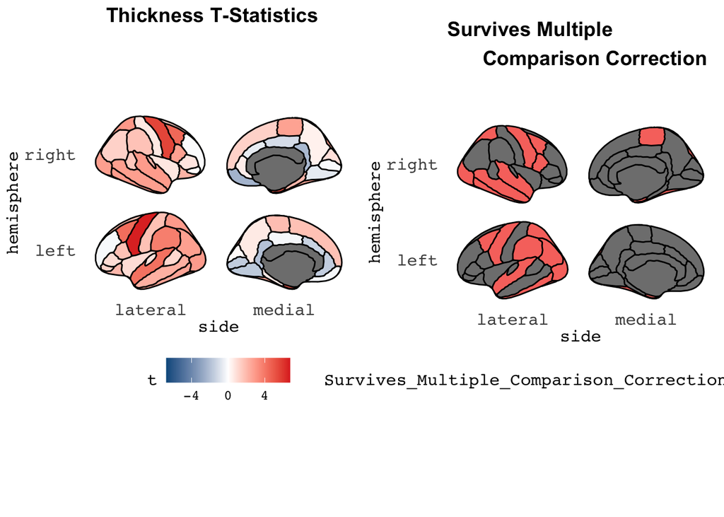

```r
plot_grid(THICK_p1, THICK_p2,labels = c('Thickness T-Statistics', 'Survives Multiple \n Comparison Correction'))
```

Again, we also output a Table showing the stats for  
QC and thickness  
with adjusted and unadjusted p-values  
For the folks who like tables, etc.  
**Table 3**

```r
dk_statistical_values_THICK_T_p %>% mutate_if(is.numeric, round, 5) %>% rename('t_statistics' = 't')  %>% rename('p_value' = 'p') %>% rename('Thickness Parcel' = 'label') %>% gt() %>% tab_style(style = cell_fill(color = "#fc9272"),locations = cells_body(columns = "p_adjusted", rows = (p_adjusted<.05)))  %>% tab_style(style = cell_fill(color = "#fee0d2"),locations = cells_body(columns = "p_value", rows = (p_value<.05))) %>% tab_options(table.font.size = "smaller",column_labels.font.size = "small",data_row.padding = px(1))
```

| Thickness Parcel | t_statistics | p_value | p_adjusted |
| --- | --- | --- | --- |
| lh_bankssts | 1.08997 | 0.27700 | 0.40948 |
| lh_caudalanteriorcingulate | -1.34432 | 0.18032 | 0.29907 |
| lh_caudalmiddlefrontal | 4.30970 | 0.00003 | 0.00022 |
| lh_cuneus | 0.15952 | 0.87342 | 0.91373 |
| lh_entorhinal | 5.07313 | 0.00000 | 0.00001 |
| lh_fusiform | 2.68890 | 0.00776 | 0.02526 |
| lh_inferiorparietal | 2.74840 | 0.00652 | 0.02463 |
| lh_inferiortemporal | 2.60408 | 0.00988 | 0.03055 |
| lh_isthmuscingulate | -1.90339 | 0.05838 | 0.12807 |
| lh_lateraloccipital | 2.86879 | 0.00455 | 0.02062 |
| lh_lateralorbitofrontal | 2.02652 | 0.04400 | 0.10011 |
| lh_lingual | -1.65309 | 0.09983 | 0.18348 |
| lh_medialorbitofrontal | -0.23206 | 0.81673 | 0.88155 |
| lh_middletemporal | 2.26172 | 0.02476 | 0.06734 |
| lh_parahippocampal | 0.60225 | 0.54767 | 0.65336 |
| lh_paracentral | 1.85395 | 0.06518 | 0.13850 |
| lh_parsopercularis | 1.76791 | 0.07856 | 0.15382 |
| lh_parsorbitalis | 1.22890 | 0.22051 | 0.33322 |
| lh_parstriangularis | 1.00086 | 0.31807 | 0.45060 |
| lh_pericalcarine | -1.57667 | 0.11641 | 0.20831 |
| lh_postcentral | 1.76425 | 0.07917 | 0.15382 |
| lh_posteriorcingulate | -0.24391 | 0.80755 | 0.88155 |
| lh_precentral | 6.57110 | 0.00000 | 0.00000 |
| lh_precuneus | 0.61377 | 0.54005 | 0.65336 |
| lh_rostralanteriorcingulate | -1.52622 | 0.12849 | 0.21843 |
| lh_rostralmiddlefrontal | -0.18503 | 0.85339 | 0.90672 |
| lh_superiorfrontal | 1.77457 | 0.07745 | 0.15382 |
| lh_superiorparietal | 2.90099 | 0.00412 | 0.02058 |
| lh_superiortemporal | 4.18747 | 0.00004 | 0.00032 |
| lh_supramarginal | 3.78244 | 0.00020 | 0.00138 |
| lh_frontalpole | -1.29074 | 0.19824 | 0.30869 |
| lh_temporalpole | 5.46017 | 0.00000 | 0.00000 |
| lh_transversetemporal | 0.81222 | 0.41760 | 0.55680 |
| lh_insula | 0.97027 | 0.33305 | 0.46219 |
| rh_bankssts | 1.55943 | 0.12043 | 0.20998 |
| rh_caudalanteriorcingulate | -0.57201 | 0.56794 | 0.66586 |
| rh_caudalmiddlefrontal | 4.45687 | 0.00001 | 0.00013 |
| rh_cuneus | 0.89066 | 0.37415 | 0.50884 |
| rh_entorhinal | 5.28642 | 0.00000 | 0.00001 |
| rh_fusiform | 2.58405 | 0.01046 | 0.03091 |
| rh_inferiorparietal | 1.28643 | 0.19974 | 0.30869 |
| rh_inferiortemporal | 2.89207 | 0.00424 | 0.02058 |
| rh_isthmuscingulate | -2.20428 | 0.02861 | 0.07483 |
| rh_lateraloccipital | 2.78964 | 0.00577 | 0.02372 |
| rh_lateralorbitofrontal | 2.17463 | 0.03080 | 0.07756 |
| rh_lingual | -0.63065 | 0.52897 | 0.65336 |
| rh_medialorbitofrontal | -2.37653 | 0.01839 | 0.05211 |
| rh_middletemporal | 2.78051 | 0.00593 | 0.02372 |
| rh_parahippocampal | 2.02490 | 0.04417 | 0.10011 |
| rh_paracentral | 2.68693 | 0.00780 | 0.02526 |
| rh_parsopercularis | 2.71333 | 0.00722 | 0.02526 |
| rh_parsorbitalis | 0.12045 | 0.90424 | 0.91774 |
| rh_parstriangularis | 0.75355 | 0.45198 | 0.59105 |
| rh_pericalcarine | -0.14035 | 0.88852 | 0.91545 |
| rh_postcentral | 0.64465 | 0.51987 | 0.65336 |
| rh_posteriorcingulate | -1.05990 | 0.29043 | 0.42020 |
| rh_precentral | 5.57632 | 0.00000 | 0.00000 |
| rh_precuneus | 0.38736 | 0.69889 | 0.79208 |
| rh_rostralanteriorcingulate | 0.49376 | 0.62200 | 0.71688 |
| rh_rostralmiddlefrontal | -0.09858 | 0.92157 | 0.92157 |
| rh_superiorfrontal | 1.29407 | 0.19709 | 0.30869 |
| rh_superiorparietal | 2.97047 | 0.00333 | 0.02056 |
| rh_superiortemporal | 2.89752 | 0.00417 | 0.02058 |
| rh_supramarginal | 1.71206 | 0.08839 | 0.16696 |
| rh_frontalpole | -0.28271 | 0.77768 | 0.86692 |
| rh_temporalpole | 5.11553 | 0.00000 | 0.00001 |
| rh_transversetemporal | 2.07574 | 0.03916 | 0.09510 |
| rh_insula | 0.71959 | 0.47259 | 0.60635 |

```r
range(dk_statistical_values_THICK_T_p$t)
```

```
## [1] -2.376528  6.571101
```

```r
mean(dk_statistical_values_THICK_T_p$t)
```

```
## [1] 1.510123
```

```r
sd(dk_statistical_values_THICK_T_p$t)
```

```
## [1] 2.04288
```

```r
table(dk_statistical_values_THICK_T_p$p>.05)
```

```
##
## FALSE  TRUE
##    30    38
```

```r
table(is.na(THICK_Multiple_Comparisons))
```

```
##
## FALSE  TRUE
##    23    45
```

Final set of loops and data organization  
This final time for the subcortical volumes  
[ Same tibbling and regression loops, etc.]  
**Figure 7**

```r
OnlySubsPassingVisualQC_Freesurfer_ASEG<-OnlySubsPassingVisualQC[,14:58]
OnlySubsPassingVisualQC_Freesurfer_ASEG<-OnlySubsPassingVisualQC_Freesurfer_ASEG %>% dplyr::select(-c(Left.Cerebellum.White.Matter, Left.Cerebellum.Cortex, Left.Lateral.Ventricle,Left.Inf.Lat.Vent,X3rd.Ventricle,X4th.Ventricle,CSF,Left.vessel,Left.choroid.plexus,Right.Cerebellum.White.Matter,Right.Cerebellum.Cortex,Right.Lateral.Ventricle,Right.Inf.Lat.Vent,Right.vessel,Right.choroid.plexus,X5th.Ventricle,WM.hypointensities,Left.WM.hypointensities,Right.WM.hypointensities,non.WM.hypointensities,Left.non.WM.hypointensities,Right.non.WM.hypointensities,Optic.Chiasm))
CAT12Ratings<-OnlySubsPassingVisualQC$CAT12_QC_Weighted_Average

## Regression Loop, with Aseg as DV and Age & QC as IVs
n<-22
ASEG_Loop_to_Extract_Tstats <- lapply(1:n, function(x) lm(OnlySubsPassingVisualQC_Freesurfer_ASEG[,x] ~ + CAT12Ratings))

## Pull out T-Statistics from Regressions
ASEG_summaries  <- lapply(ASEG_Loop_to_Extract_Tstats, summary)
ASEG_saved_T<-lapply(ASEG_summaries, function(x) x$coefficients[, c(3)])
ASEG_T_Statistics_temp<-lapply(ASEG_saved_T, function (x) x[c('CAT12Ratings')])
ASEG_just_T_Statistics<-do.call(rbind.data.frame, ASEG_T_Statistics_temp)
names(ASEG_just_T_Statistics)[1] <- "T_stat"

## Rename and Reorder the data frames (related to t-statistics)
ASEG_just_T_Statistics$BrainRegions<-(colnames(OnlySubsPassingVisualQC_Freesurfer_ASEG)[1:22])
ASEG_just_T_Statistics<-ASEG_just_T_Statistics[, c(2,1)]

## Pull out P-Values from Regressions
ASEG_saved_p<-lapply(ASEG_summaries, function(x) x$coefficients[, c(4)])
ASEG_p_Statistics_temp<-lapply(ASEG_saved_p, function (x) x[c('CAT12Ratings')])
ASEG_just_p_Statistics<-do.call(rbind.data.frame, ASEG_p_Statistics_temp)
names(ASEG_just_p_Statistics)[1] <- "pvalue"

## Rename and Reorder the data frames (related to p-values)
ASEG_just_p_Statistics$BrainRegions<-(colnames(OnlySubsPassingVisualQC_Freesurfer_ASEG)[1:22])
ASEG_just_p_Statistics<-ASEG_just_p_Statistics[, c(2,1)]

# Make tibble to eventually put into ggseg [for t-statistics]
aseg_statistical_values_T= tibble(
  label=c("Left-Thalamus-Proper",
          "Left-Caudate",
          "Left-Putamen",
          "Left-Pallidum",
          "brain-stem",
          "Left-Hippocampus",
          "Left-Amygdala",
          "Left-Accumbens-area",
          "Left-VentralDC",
          "Right-Thalamus-Proper",
          "Right-Caudate",
          "Right-Putamen",
          "Right-Pallidum",
          "Right-Hippocampus",
          "Right-Amygdala",
          "Right-Accumbens-area",
          "Right-VentralDC",
          "cc-posterior",
          "cc-mid-posterior",
          "cc-central",
          "cc-mid-anterior",
          "cc-anterior"),
  t=c(ASEG_just_T_Statistics$T_stat[1],
      ASEG_just_T_Statistics$T_stat[2],
      ASEG_just_T_Statistics$T_stat[3],
      ASEG_just_T_Statistics$T_stat[4],
      ASEG_just_T_Statistics$T_stat[5],
      ASEG_just_T_Statistics$T_stat[6],
      ASEG_just_T_Statistics$T_stat[7],
      ASEG_just_T_Statistics$T_stat[8],
      ASEG_just_T_Statistics$T_stat[9],
      ASEG_just_T_Statistics$T_stat[10],
      ASEG_just_T_Statistics$T_stat[11],
      ASEG_just_T_Statistics$T_stat[12],
      ASEG_just_T_Statistics$T_stat[13],
      ASEG_just_T_Statistics$T_stat[14],
      ASEG_just_T_Statistics$T_stat[15],
      ASEG_just_T_Statistics$T_stat[16],
      ASEG_just_T_Statistics$T_stat[17],
      ASEG_just_T_Statistics$T_stat[18],
      ASEG_just_T_Statistics$T_stat[19],
      ASEG_just_T_Statistics$T_stat[20],
      ASEG_just_T_Statistics$T_stat[21],
      ASEG_just_T_Statistics$T_stat[22]))

# Make tibble to eventually put into ggseg [for p-values]
aseg_statistical_values_p= tibble(
  label=c("Left-Thalamus-Proper",
          "Left-Caudate",
          "Left-Putamen",
          "Left-Pallidum",
          "brain-stem",
          "Left-Hippocampus",
          "Left-Amygdala",
          "Left-Accumbens-area",
          "Left-VentralDC",
          "Right-Thalamus-Proper",
          "Right-Caudate",
          "Right-Putamen",
          "Right-Pallidum",
          "Right-Hippocampus",
          "Right-Amygdala",
          "Right-Accumbens-area",
          "Right-VentralDC",
          "cc-posterior",
          "cc-mid-posterior",
          "cc-central",
          "cc-mid-anterior",
          "cc-anterior"),
  p=c(ASEG_just_p_Statistics$pvalue[1],
      ASEG_just_p_Statistics$pvalue[2],
      ASEG_just_p_Statistics$pvalue[3],
      ASEG_just_p_Statistics$pvalue[4],
      ASEG_just_p_Statistics$pvalue[5],
      ASEG_just_p_Statistics$pvalue[6],
      ASEG_just_p_Statistics$pvalue[7],
      ASEG_just_p_Statistics$pvalue[8],
      ASEG_just_p_Statistics$pvalue[9],
      ASEG_just_p_Statistics$pvalue[10],
      ASEG_just_p_Statistics$pvalue[11],
      ASEG_just_p_Statistics$pvalue[12],
      ASEG_just_p_Statistics$pvalue[13],
      ASEG_just_p_Statistics$pvalue[14],
      ASEG_just_p_Statistics$pvalue[15],
      ASEG_just_p_Statistics$pvalue[16],
      ASEG_just_p_Statistics$pvalue[17],
      ASEG_just_p_Statistics$pvalue[18],
      ASEG_just_p_Statistics$pvalue[19],
      ASEG_just_p_Statistics$pvalue[20],
      ASEG_just_p_Statistics$pvalue[21],
      ASEG_just_p_Statistics$pvalue[22]))

# Multiple Comparison Correction
aseg_statistical_values_p$p_adjusted<-p.adjust(aseg_statistical_values_p$p, method = "BH", n = length(aseg_statistical_values_p$p))
aseg_statistical_values_T_p <- aseg_statistical_values_T %>% left_join(aseg_statistical_values_p)
```

```r
Aseg_Multiple_Comparisons<-as_tibble(as.numeric(aseg_statistical_values_p$p_adjusted<.05))
Aseg_Multiple_Comparisons<-Aseg_Multiple_Comparisons %>% mutate(value=recode(value,0,1))

names(Aseg_Multiple_Comparisons)[names(Aseg_Multiple_Comparisons)=="value"] <- "Survives_Multiple_Comparison_Correction"

aseg_statistical_values_T_w_MultipleComparisons <- cbind(aseg_statistical_values_T, Aseg_Multiple_Comparisons)

aseg_p1<-ggseg(aseg_statistical_values_T,atlas=aseg,position = "stacked",mapping=aes(fill=t,color=Survives_Multiple_Comparison_Correction),colour="black") + scale_fill_gradient2(low = "#045a8d",high = "#de2d26",space = "Lab",limits = c(-6.75, 6.75))+theme(legend.position = "bottom")
```

```
## merging atlas and data by 'label'
```

```r
aseg_p2<-ggseg(aseg_statistical_values_T_w_MultipleComparisons,atlas=aseg,position = "stacked",mapping=aes(fill=Survives_Multiple_Comparison_Correction),color="black")+theme(legend.position = "bottom")
```

```
## merging atlas and data by 'label'
```

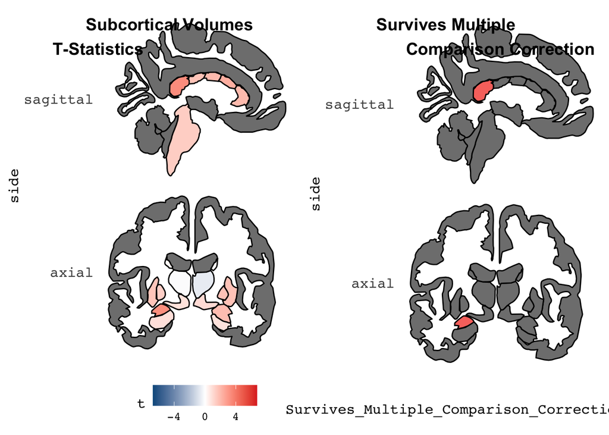

```r
plot_grid(aseg_p1, aseg_p2,labels = c('Subcortical Volumes \n T-Statistics', 'Survives Multiple \n Comparison Correction'))
```

Again, we also output a Table showing the stats for  
QC and aseg volumes  
with adjusted and unadjusted p-values  
For the folks who like tables, etc.  
**Table 4**

```r
aseg_statistical_values_T_p %>% mutate_if(is.numeric, round, 5) %>% rename('t_statistics' = 't')  %>% rename('p_value' = 'p') %>% rename('Aseg_Volume' = 'label') %>% gt() %>% tab_style(style = cell_fill(color = "#fc9272"),locations = cells_body(columns = "p_adjusted", rows = (p_adjusted<.05)))  %>% tab_style(style = cell_fill(color = "#fee0d2"),locations = cells_body(columns = "p_value", rows = (p_value<.05))) %>% tab_options(table.font.size = "smaller",column_labels.font.size = "small",data_row.padding = px(1))
```

| Aseg_Volume | t_statistics | p_value | p_adjusted |
| --- | --- | --- | --- |
| Left-Thalamus-Proper | -0.10352 | 0.91765 | 0.97864 |
| Left-Caudate | 0.18568 | 0.85288 | 0.97864 |
| Left-Putamen | 1.64437 | 0.10163 | 0.22358 |
| Left-Pallidum | 1.32804 | 0.18563 | 0.31415 |
| brain-stem | 1.39762 | 0.16373 | 0.30017 |
| Left-Hippocampus | 0.87275 | 0.38381 | 0.55460 |
| Left-Amygdala | 3.26946 | 0.00126 | 0.01389 |
| Left-Accumbens-area | 0.02680 | 0.97864 | 0.97864 |
| Left-VentralDC | 0.82099 | 0.41260 | 0.55460 |
| Right-Thalamus-Proper | -0.58969 | 0.55604 | 0.67961 |
| Right-Caudate | 0.07730 | 0.93846 | 0.97864 |
| Right-Putamen | 1.71325 | 0.08817 | 0.21891 |
| Right-Pallidum | 1.74292 | 0.08284 | 0.21891 |
| Right-Hippocampus | 0.79323 | 0.42856 | 0.55460 |
| Right-Amygdala | 1.89779 | 0.05912 | 0.21678 |
| Right-Accumbens-area | 1.48388 | 0.13937 | 0.27874 |
| Right-VentralDC | 1.01197 | 0.31274 | 0.49144 |
| cc-posterior | 3.33701 | 0.00100 | 0.01389 |
| cc-mid-posterior | 1.70579 | 0.08956 | 0.21891 |
| cc-central | 1.96198 | 0.05111 | 0.21678 |
| cc-mid-anterior | 2.33941 | 0.02027 | 0.14866 |
| cc-anterior | 1.96509 | 0.05075 | 0.21678 |

```r
range(aseg_statistical_values_T_p$t)
```

```
## [1] -0.5896917  3.3370090
```

```r
mean(aseg_statistical_values_T_p$t)
```

```
## [1] 1.312823
```

```r
sd(aseg_statistical_values_T_p$t)
```

```
## [1] 1.016237
```

```r
table(aseg_statistical_values_T_p$p>.05)
```

```
##
## FALSE  TRUE
##     3    19
```

```r
table(is.na(Aseg_Multiple_Comparisons))
```

```
##
## FALSE  TRUE
##     2    20
```